🔗 Part of the [ATRAPA database project](https://github.com/GEMOTT/atrapa_database)  
⬅️ [Back to project overview](https://github.com/GEMOTT/atrapa%20database) ➡️ [Next repo related: Electoral and socioeconomic data](https://github.com/GEMOTT/electoral-socioeconomic-data)

# Evaluating OpenStreetMap for Tracking Active Travel Infrastructure Changes: A Multi-City Validation Across Seven European Cities

## Introduction

The relationship between the built environment and travel behaviour has been widely studied, with many studies identifying associations between environmental characteristics and travel patterns (Cerin et al. 2017; Ding et al. 2011; Zhang et al. 2022). However, most research relies on cross-sectional data, which cannot establish causality (McCormack and Shiell 2011; P. van de Coevering, and Wee 2015). In contrast, studies that track changes in both travel behaviour and the built environment—such as longitudinal studies and natural experiments—offer stronger causal insights but remain relatively scarce (Kärmeniemi et al. 2018; Smith et al. 2017; Tcymbal et al. 2020).

One of the main challenges in expanding this area of research is the limited availability of consistent, time-series data on the built environment. While historical data on travel behaviour is often more accessible—through sources like censuses, surveys, and increasingly, crowdsourced platforms like Strava—comparable records of past urban infrastructure are much harder to obtain. Some national databases, such as the Netherlands’ Nationaal Wegenbestand (NWB) (P. V. D. Coevering et al. 2016), provide road network data going back over decades, but these are rare and typically limited to a single country or region, hindering broader or international comparisons. An alternative is to reconstruct historical built environment data manually using maps, satellite imagery, and planning records, but this process is highly resource-intensive and typically limited in scale.

The growing availability of Volunteered Geographic Information (VGI) presents new opportunities to overcome data limitations in built environment research. Among these sources, OpenStreetMap (OSM) stands out for providing open, editable, and historical data on various types of infrastructure, making it a promising tool for analysing urban transformations over time. However, its application in this context requires careful validation due to well-documented limitations in accuracy, completeness, and temporal consistency (Barron, Neis, and Zipf 2014; Zielstra and Zipf, n.d.).

While OSM has been widely used to assess infrastructure coverage and routing potential, its reliability for capturing historical transformations—especially in pedestrian-oriented infrastructure—remains unclear. This study aims to evaluate the extent to which historical OSM data can reliably capture urban transformations in active travel infrastructure—such as bike lanes, pedestrian streets, and living streets—across multiple European cities. We develop and apply a semi-automated validation method that compares reported changes in OSM to external reference sources, including street-level and satellite imagery as well as official records. The analysis focuses on seven cities selected for their relevance to a broader research initiative and uses stratified sampling to reflect socio-demographic and spatial diversity. While the present study is limited to these cases, the framework is designed to be scalable and transferable, offering a practical tool for researchers and planners seeking to monitor infrastructure change over time.

This study builds on recent efforts to assess OSM’s data quality and potential for infrastructure analysis, with particular attention to its capacity to represent change over time.

## Literature review

OSM is often used to study transport infrastructure—especially cycling networks—but few studies examine how these networks change over time. A countrywide assessment in Denmark found that neither OSM nor the official GeoDanmark dataset alone provided complete coverage; feature-level conflation was necessary to improve reliability, especially in rural areas (Vierø, Vybornova, and Szell 2025). Viero et al. also introduced BikeDNA, an open-source tool that validates OSM cycling data with attention to network topology, local completeness, and spatial variation (Vierø, Vybornova, and Szell 2024). Similarly, Ferster et al. compared OSM with municipal datasets in six Canadian cities and found high agreement in total network length, though accuracy varied by infrastructure type—especially for newer or inconsistently tagged features (Ferster et al. 2023). These studies underscore both the promise and the limitations of OSM for cycling infrastructure research.

In contrast, pedestrian networks—especially pedestrianized and living streets—have received significantly less attention in OSM validation studies. While some efforts have focused on sidewalks or routing networks (e.g. Zielstra and Hochmair (2012); https://wiki.openstreetmap.org/wiki/OpenSidewalks), few have assessed whether OSM reliably represents pedestrianized streets (e.g., highway=pedestrian) or living streets (highway=living_street), or whether these features accurately reflect real-world transformations over time. These types of infrastructure are increasingly relevant for sustainable mobility but pose unique challenges for mapping and validation due to tagging ambiguity and definitional variation across contexts (National Technical University of Athens, Greece 2022; Omar et al. 2022).

Taken together, these studies demonstrate that OSM is a promising yet uneven source for analyzing changes in the built environment. However, most existing research focuses on static comparisons, routing applications, or cycling-specific infrastructure—often within single cities or countries. Very few studies assess OSM’s ability to capture infrastructure transformations over time, particularly for underrepresented networks like pedestrian and living streets. Our study addresses this gap by developing a validation framework that compares reported OSM transformations to multiple external sources—Google Street View, satellite imagery, and official municipal records—across seven European cities. In doing so, we assess the temporal completeness, spatial variation, and overall reliability of OSM as a longitudinal dataset for tracking changes in active travel infrastructure.

## Data and Method

### Data Sources

- OpenStreetMap (OSM) historical snapshots (2015–2023)
- Google Street View (GSV) imagery
- Satellite imagery (e.g., Google Earth Pro, Sentinel-2)
- Official municipal records

### Validation Approach

#### 1. Sampling Strategy

- **Stratified Random Spatial Sampling**: Each city will be divided into small-area units (e.g., neighborhoods, electoral wards, or blocks).
- **Stratification** based on:
  - Geographic characteristics (city center, suburban, peripheral)
  - Socio-demographic factors (income level, population density)
- Randomly select small-area units from each stratum to ensure unbiased and representative validation.

#### 2. Transformation Validation

For each selected small-area unit:

- Extract infrastructure data from OSM snapshots for two intervals:
  - 2015–2019
  - 2019–2023
- Identify transformations reported by OSM within each interval.
- Independently verify these transformations using external reference data:
  - Google Street View (GSV) for visual confirmation
  - Satellite imagery for cross-validation
  - Official municipal records as authoritative validation sources

#### 3. Metrics and Analysis

Compute three core metrics for each city, each interval, each infrastructure type, and each small area:

- **Completeness of transformations**:  
  `Completeness = (Number of transformations correctly identified in OSM) / (Total actual transformations from validation sources)`
- **Accuracy of transformations**:  
  `Accuracy = (Number of transformations correctly identified in OSM) / (Total transformations reported by OSM)`
- **Spatial Completeness Index (SCI)**:  
  Measures the spatial variability of completeness across small areas within each city (e.g., standard deviation or range of completeness).

### City Inclusion Criteria

Cities and intervals will be included in the analysis only if the majority of small areas meet **two thresholds**:

- **Overall Completeness**: ≥ 80%
- **SCI (Spatial Variation)**: ≤ 15%

These thresholds are grounded in prior research and established best practices:

- 80% completeness threshold:  
  Used in prior OSM validation studies (Hochmair et al., 2014; Zielstra & Zipf, 2010; Barron et al., 2014)
- ≤15% spatial variation threshold:  
  Based on geospatial sampling practices ensuring representative distribution (Elwood & Goodchild, 2013)

#### Example Evaluation Table by Interval and Infrastructure Type

| City | Interval | Type | Completeness | SCI | Accuracy | Decision |
| --- | --- | --- | --- | --- | --- | --- |
| Barcelona | 2015–2019 | Bike Lanes | 88% ✅ | 9% ✅ | 91% ✅ | ✅ Include |
| Barcelona | 2015–2019 | Pedestrian | 84% ✅ | 12% ✅ | 87% ✅ | ✅ Include |
| Barcelona | 2015–2019 | Living Streets | 72% ❌ | 18% ❌ | 78% ❌ | ❌ Exclude |
| Paris | 2019–2023 | Bike Lanes | 78% ❌ | 14% ✅ | 82% ✅ | ⚠️ Conditional |
| Paris | 2019–2023 | Pedestrian | 83% ✅ | 17% ❌ | 85% ✅ | ⚠️ Conditional |
| Warsaw | 2015–2019 | Bike Lanes | 70% ❌ | 10% ✅ | 75% ❌ | ❌ Exclude |
| Milan | 2019–2023 | Bike Lanes | 90% ✅ | 11% ✅ | 89% ✅ | ✅ Include |

## Results

### OSM data Barcelona

#### Road network by type

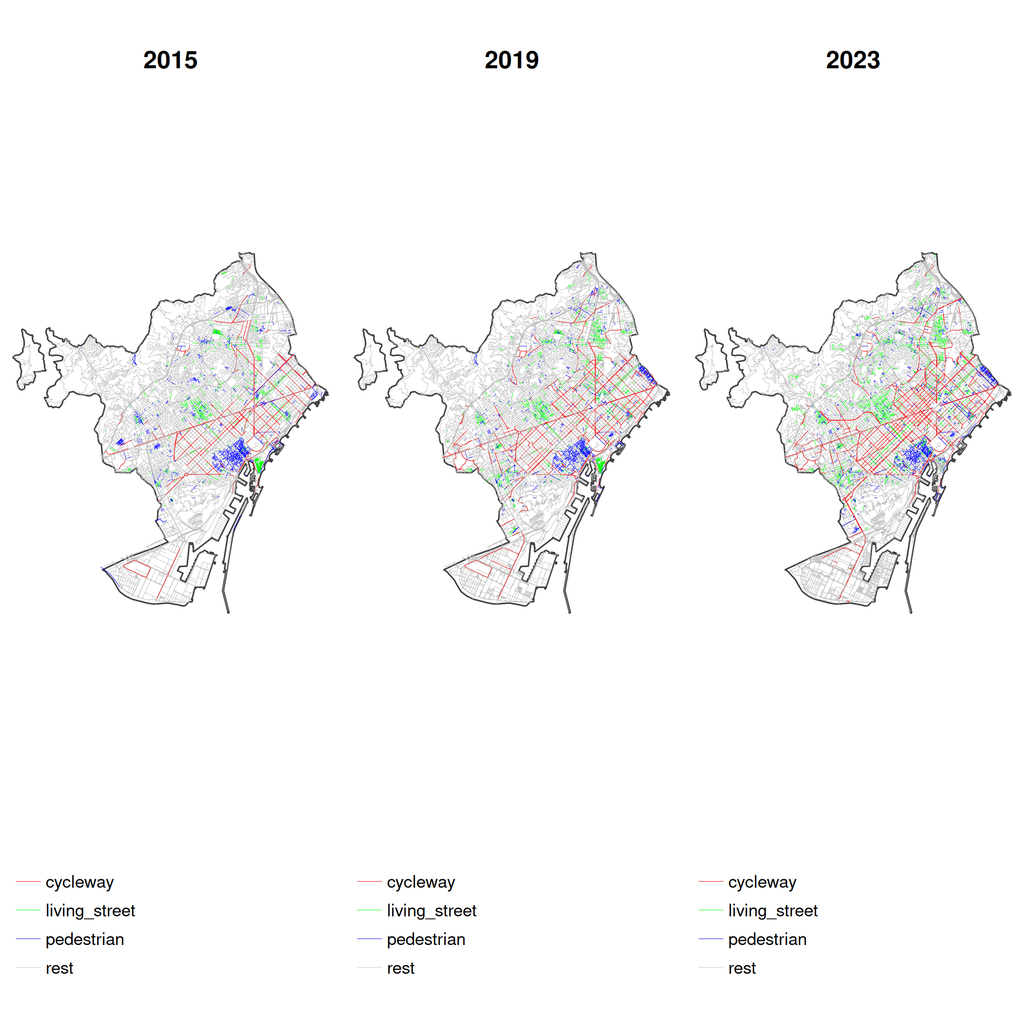

#### Indicators at the census tract level

- Cycleway Proportion of Total Network

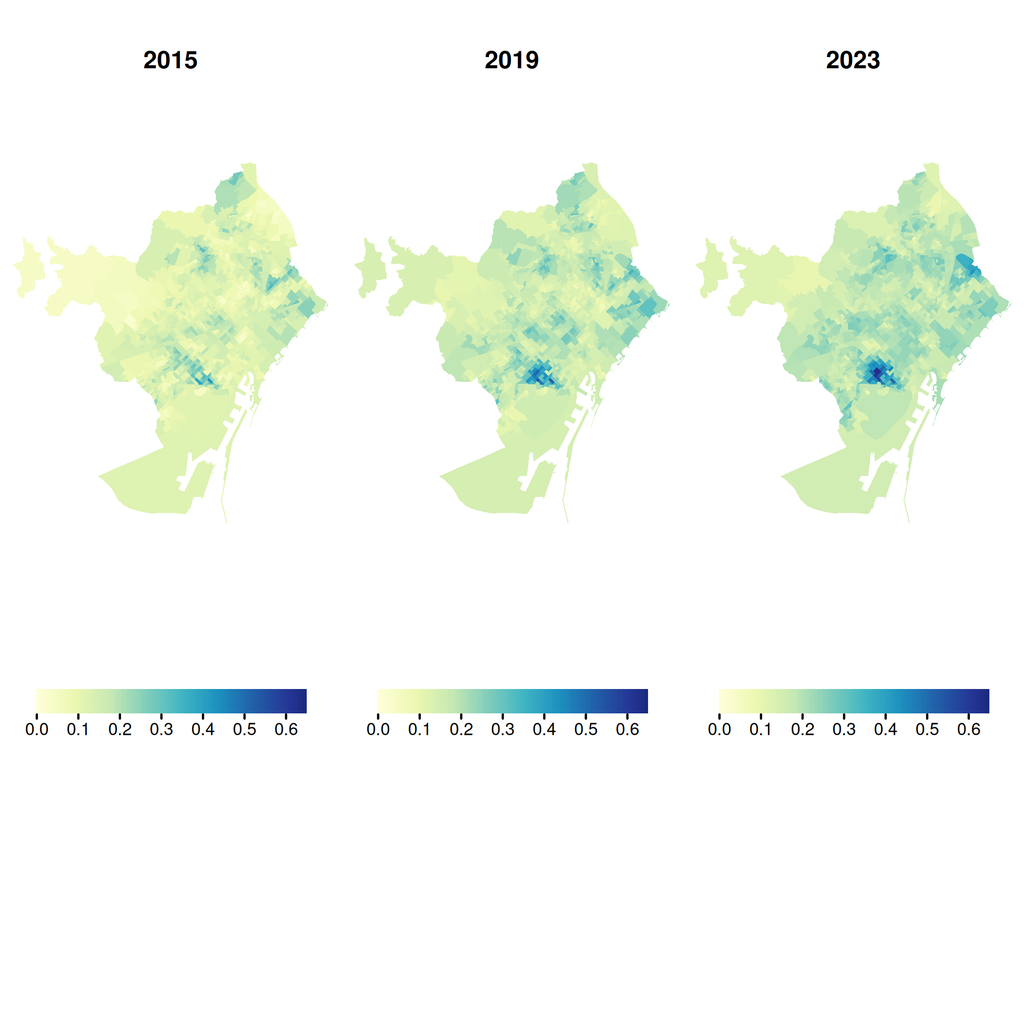

- Living Street Proportion of Total Network

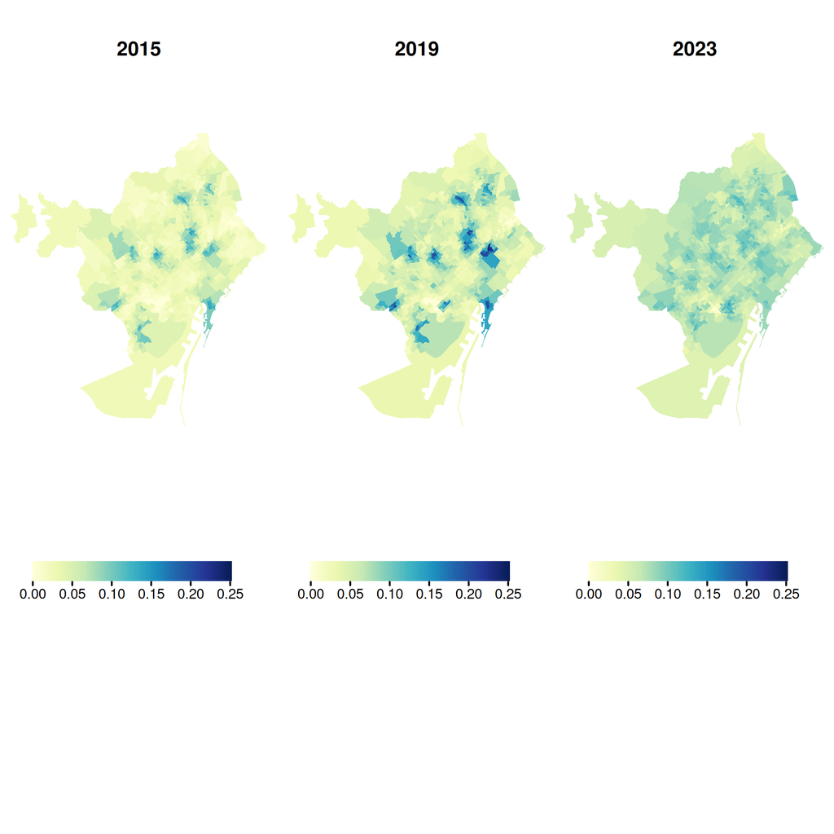

- Pedestrian Street Proportion of Total Network

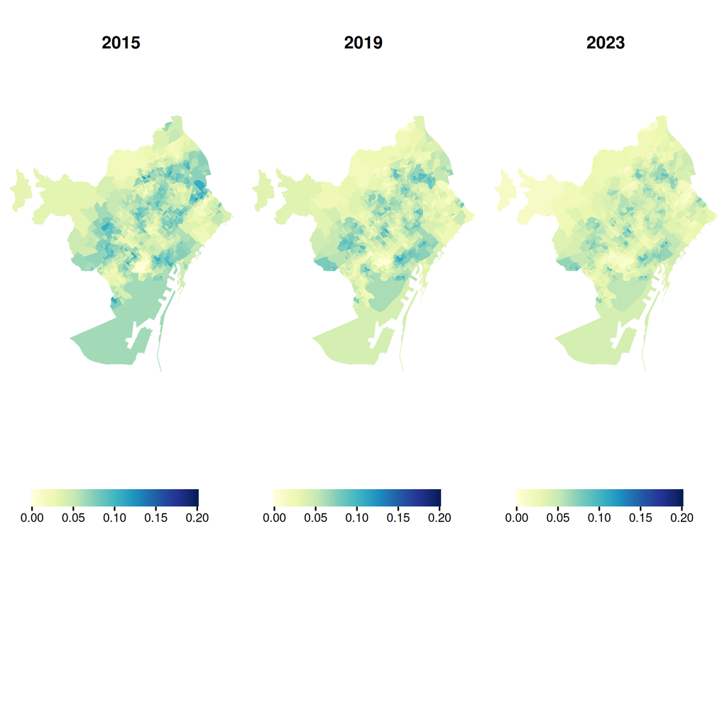

# References

Barron, Christopher, Pascal Neis, and Alexander Zipf. 2014. “A Comprehensive Framework for Intrinsic OpenStreetMap Quality Analysis.” *Transactions in GIS* 18 (6): 877–95. https://doi.org/10.1111/tgis.12073.

Cerin, Ester, Andrea Nathan, Jelle van Cauwenberg, David W. Barnett, Anthony Barnett, and on behalf of the Council on Environment and Physical Activity (CEPA) – Older Adults working group. 2017. “The Neighbourhood Physical Environment and Active Travel in Older Adults: A Systematic Review and Meta-Analysis.” *International Journal of Behavioral Nutrition and Physical Activity* 14 (1): 15. https://doi.org/10.1186/s12966-017-0471-5.

Coevering, Paul Van De, Kees Maat, Maarten Kroesen, and Bert Van Wee. 2016. “Causal Effects of Built Environment Characteristics on Travel Behaviour: A Longitudinal Approach.” *European Journal of Transport and Infrastructure Research*. https://doi.org/10.18757/EJTIR.2016.16.4.3165.

Coevering, Paul van de, Maat, and Bert and van Wee. 2015. “Multi-Period Research Designs for Identifying Causal Effects of Built Environment Characteristics on Travel Behaviour.” *Transport Reviews* 35 (4): 512–32. https://doi.org/10.1080/01441647.2015.1025455.

Ding, Ding, James F. Sallis, Jacqueline Kerr, Suzanna Lee, and Dori E. Rosenberg. 2011. “Neighborhood Environment and Physical Activity Among Youth.” *American Journal of Preventive Medicine* 41 (4): 442–55. https://doi.org/10.1016/j.amepre.2011.06.036.

Ferster, Colin, Trisalyn Nelson, Kevin Manaugh, Jeneva Beairsto, Karen Laberee, and Meghan Winters. 2023. “Developing a National Dataset of Bicycle Infrastructure for Canada Using Open Data Sources.” *Environment and Planning B: Urban Analytics and City Science* 50 (9): 2543–59. https://doi.org/10.1177/23998083231159905.

Kärmeniemi, Mikko, Tiina Lankila, Tiina Ikäheimo, Heli Koivumaa-Honkanen, and Raija Korpelainen. 2018. “The Built Environment as a Determinant of Physical Activity: A Systematic Review of Longitudinal Studies and Natural Experiments.” *Annals of Behavioral Medicine* 52 (3): 239–51. https://doi.org/10.1093/abm/kax043.

McCormack, Gavin R., and Alan Shiell. 2011. “In Search of Causality: A Systematic Review of the Relationship Between the Built Environment and Physical Activity Among Adults.” *International Journal of Behavioral Nutrition and Physical Activity* 8 (1): 125. https://doi.org/10.1186/1479-5868-8-125.

National Technical University of Athens, Greece. 2022. “Utilizing OpenStreetMap Data to Measure and Compare Pedestrian Street Lengths in 992 Cities Around the World.” *European Journal of Geography* 13 (2): 127–41. https://doi.org/10.48088/ejg.a.bar.13.2.127.138.

Omar, Kazi Shahrukh, Gustavo Moreira, Daniel Hodczak, Maryam Hosseini, and Fabio Miranda. 2022. “Crowdsourcing and Sidewalk Data: A Preliminary Study on the Trustworthiness of OpenStreetMap Data in the US.” arXiv. https://doi.org/10.48550/arXiv.2210.02350.

Smith, Melody, Jamie Hosking, Alistair Woodward, Karen Witten, Alexandra MacMillan, Adrian Field, Peter Baas, and Hamish Mackie. 2017. “Systematic Literature Review of Built Environment Effects on Physical Activity and Active Transport – an Update and New Findings on Health Equity.” *International Journal of Behavioral Nutrition and Physical Activity* 14 (1): 158. https://doi.org/10.1186/s12966-017-0613-9.

Tcymbal, Antonina, Yolanda Demetriou, Anne Kelso, Laura Wolbring, Kathrin Wunsch, Hagen Wäsche, Alexander Woll, and Anne K. Reimers. 2020. “Effects of the Built Environment on Physical Activity: A Systematic Review of Longitudinal Studies Taking Sex/Gender into Account.” *Environmental Health and Preventive Medicine* 25 (1): 75. https://doi.org/10.1186/s12199-020-00915-z.

Vierø, Ane Rahbek, Anastassia Vybornova, and Michael Szell. 2024. “BikeDNA: A Tool for Bicycle Infrastructure Data & Network Assessment.” *Environment and Planning B: Urban Analytics and City Science* 51 (2): 512–28. https://doi.org/10.1177/23998083231184471.

———. 2025. “How Good Is Open Bicycle Network Data? A Countrywide Case Study of Denmark.” *Geographical Analysis* 57 (1): 52–87. https://doi.org/10.1111/gean.12400.

Zhang, Yufang, Marijke Koene, Sijmen A. Reijneveld, Jolanda Tuinstra, Manda Broekhuis, Stefan van der Spek, and Cor Wagenaar. 2022. “The Impact of Interventions in the Built Environment on Physical Activity Levels: A Systematic Umbrella Review.” *International Journal of Behavioral Nutrition and Physical Activity* 19 (1): 156. https://doi.org/10.1186/s12966-022-01399-6.

Zielstra, Dennis, and Hartwig H. Hochmair. 2012. “Using Free and Proprietary Data to Compare Shortest-Path Lengths for Effective Pedestrian Routing in Street Networks.” *Transportation Research Record* 2299 (1): 41–47. https://doi.org/10.3141/2299-05.

Zielstra, Dennis, and Alexander Zipf. n.d. “A Comparative Study of Proprietary Geodata and Volunteered Geographic Information for Germany.”